# ПРЕДИКТИВНАЯ СИСТЕМА ОЦЕНКИ КАЧЕСТВА ГОТОВОЙ ПРОДУКЦИИ НА ОСНОВЕ РЕЦЕПТУРЫ ШИХТЫ

# Target по агрегатам

```
================================================================================
TARGET ПО AGGREGATE
================================================================================
```

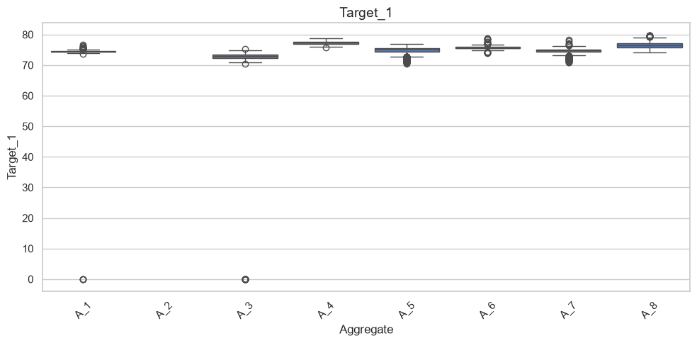

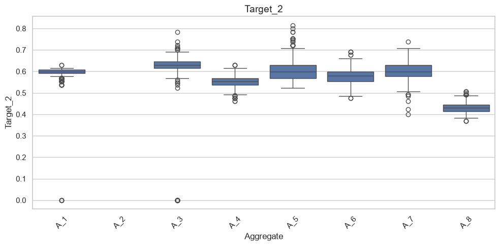

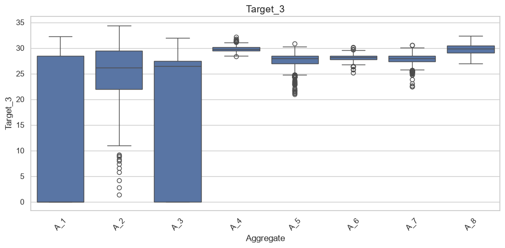

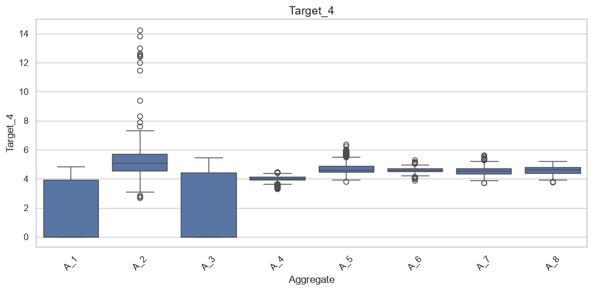

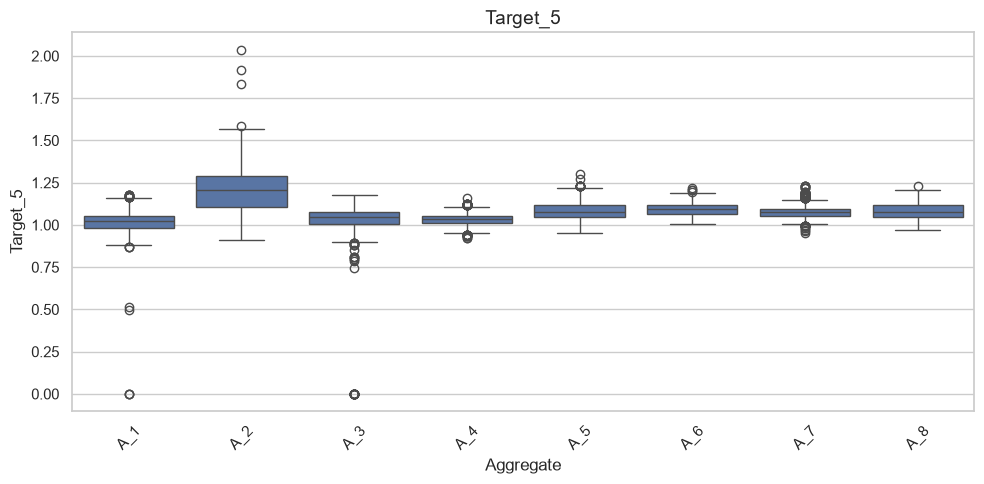

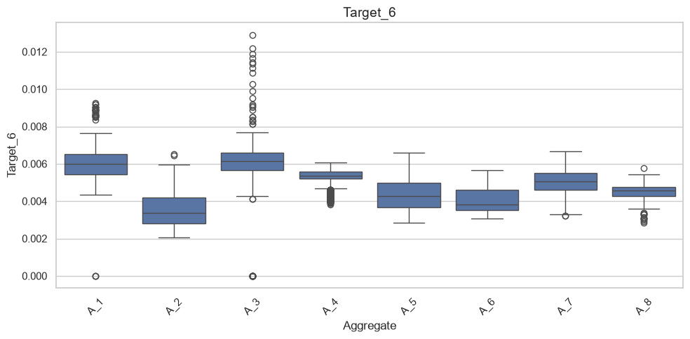

```python
print("\n" + "=" * 80)
print("TARGET ПО AGGREGATE")
print("=" * 80)

for target in target_cols:
    plt.figure(figsize=(10,5))
    sns.boxplot(data=df, x="Aggregate", y=target)
    plt.xticks(rotation=45)
    plt.title(target)
    plt.tight_layout()
    plt.show()
```

**ВЫВОДЫ по Target по агрегатам:**

Анализ **box-plot'ов** подтверждает критическую зависимость качества от агрегата: для `Target_1` и `Target_2` наблюдается сегментация (`A_8` даёт более высокий `T1` и низкий `T2`, `A_5` — обратную картину, `A_2` полностью отсутствует), а для `Target_3` и `Target_4` различия ещё драматичнее — агрегаты `A_1–A_3` имеют широкие размахи и множество выбросов, тогда как `A_4–A_8` стабильны с высокими медианами. Единая глобальная модель без учёта агрегата усреднит эти различия и потеряет точность; технолог должен учитывать специфику каждого агрегата (например, выполнение норматива **T1=75** проблематично для `A_5`, но достижимо для `A_8`). Рекомендуется использовать агрегат как категориальный признак (`target encoding` или `one-hot`) либо строить ансамбль моделей на кластерах схожих агрегатов, чтобы захватить локальные закономерности и базовые уровни процесса.

# Статистические различия между агрегатами

```python
print("\n" + "=" * 80)
print("КРУСКАЛ-УОЛЛИС")
print("=" * 80)

aggregate_stats = {}

for target in target_cols:
    groups = []
    for agg in df["Aggregate"].dropna().unique():
        values = df.loc[
            df["Aggregate"] == agg, target].dropna()
        if len(values):
            groups.append(values)
    if len(groups) > 1:
        H, p = stats.kruskal(*groups)
        aggregate_stats[target] = p
        print(f"{target:10s} p-value = {p:.5g}")
```

```
================================================================================
КРУСКАЛ-УОЛЛИС
================================================================================
Target_1   p-value = 0
Target_2   p-value = 0
Target_3   p-value = 0
Target_4   p-value = 0
Target_5   p-value = 0
Target_6   p-value = 0
```

# Итоговый отчет

```python
print("\n")
print("=" * 100)
print("ИТОГОВЫЙ ОТЧЕТ EDA")
print("=" * 100)

print("\n1. Признаки с выраженными выбросами (IQR):")

if len(outlier_df):
    display(outlier_df)
else:
    print("Не обнаружены.")
print("\n2. Признаки с высокой мультиколлинеарностью (>0.85):")
if len(multicollinear_df):
    display(multicollinear_df.sort_values("Correlation", ascending=False))
else:
    print("Не обнаружены.")
print("\n3. Zero-inflated признаки (>50% нулей):")
if len(zero_features):
    print(list(zero_features.index))
else:
    print("Не обнаружены.")
print("\n4. Анализ природы пропусков")
for target in target_cols:
    pct = df[target].isna().mean()*100
    print(f"{target}: {pct:.2f}% пропусков")
```

```
====================================================================================================
ИТОГОВЫЙ ОТЧЕТ EDA
====================================================================================================

1. Признаки с выраженными выбросами (IQR):
```

|  | Feature | Outliers | Percent |
| --- | --- | --- | --- |
| 10 | Feature_12 | 2314 | 19.69865 |
| 27 | Feature_29 | 2254 | 19.18788 |
| 9 | Feature_10 | 1292 | 10.99855 |
| 8 | Feature_9 | 1231 | 10.47927 |
| 29 | Feature_31 | 1171 | 9.96850 |
| 28 | Feature_30 | 1159 | 9.86635 |
| 13 | Feature_15 | 811 | 6.90389 |
| 23 | Feature_25 | 688 | 5.85681 |
| 0 | Feature_1 | 571 | 4.86082 |
| 19 | Feature_21 | 505 | 4.29897 |
| 26 | Feature_28 | 429 | 3.65200 |
| 21 | Feature_23 | 412 | 3.50728 |
| 4 | Feature_5 | 409 | 3.48174 |
| 3 | Feature_4 | 398 | 3.38810 |
| 18 | Feature_20 | 364 | 3.09866 |
| 25 | Feature_27 | 350 | 2.97948 |
| 31 | Feature_34 | 331 | 2.81774 |
| 30 | Feature_33 | 302 | 2.57087 |
| 16 | Feature_18 | 263 | 2.23887 |
| 17 | Feature_19 | 260 | 2.21333 |
| 6 | Feature_7 | 257 | 2.18779 |
| 24 | Feature_26 | 242 | 2.06010 |
| 5 | Feature_6 | 241 | 2.05159 |
| 1 | Feature_2 | 214 | 1.82174 |
| 20 | Feature_22 | 204 | 1.73661 |
| 11 | Feature_13 | 184 | 1.56636 |
| 15 | Feature_17 | 161 | 1.37056 |
| 14 | Feature_16 | 128 | 1.08964 |
| 12 | Feature_14 | 123 | 1.04708 |
| 32 | Feature_35 | 118 | 1.00451 |
| 2 | Feature_3 | 95 | 0.80872 |
| 22 | Feature_24 | 57 | 0.48523 |
| 7 | Feature_8 | 42 | 0.35754 |

```
2. Признаки с высокой мультиколлинеарностью (>0.85):
```

|  | Feature_1 | Feature_2 | Correlation |
| --- | --- | --- | --- |
| 6 | Feature_6 | Feature_26 | 1.00000 |
| 13 | Feature_30 | Feature_33 | 0.98315 |
| 4 | Feature_22 | Feature_24 | 0.96310 |
| 15 | Feature_32 | Feature_33 | 0.93379 |
| 11 | Feature_30 | Feature_32 | 0.93274 |
| 12 | Feature_31 | Feature_32 | 0.92721 |
| 10 | Feature_30 | Feature_31 | 0.91936 |
| 9 | Feature_25 | Feature_27 | 0.91517 |
| 14 | Feature_31 | Feature_33 | 0.91164 |
| 7 | Feature_7 | Feature_26 | 0.88821 |
| 0 | Feature_6 | Feature_7 | 0.88821 |
| 5 | Feature_4 | Feature_25 | 0.88388 |
| 8 | Feature_4 | Feature_27 | 0.88152 |
| 2 | Feature_8 | Feature_24 | 0.87094 |
| 1 | Feature_8 | Feature_22 | 0.86770 |
| 3 | Feature_21 | Feature_24 | 0.85809 |

```
3. Zero-inflated признаки (>50% нулей):
['Feature_28', 'Feature_9', 'Feature_10', 'Feature_29', 'Feature_12', 'Feature_30', 'Feature_31', 'Feature_32', 'Feature_33']

4. Анализ природы пропусков
Target_1: 11.90% пропусков
Target_2: 11.71% пропусков
Target_3: 31.83% пропусков
Target_4: 31.84% пропусков
Target_5: 8.85% пропусков
Target_6: 8.83% пропусков
```

## Итоговый вывод по результатам разведочного анализа данных (EDA)

Проведённый комплексный разведочный анализ данных, охватывающий `11 747` наблюдений за период с `февраля 2014` по `август 2022` года по **8** производственным **агрегатам**, позволил сформировать целостное представление о структуре и качестве исторического массива, лежащего в основе предиктивной системы оценки качества готовой продукции. Установлено, что данные обладают выраженной структурной неоднородностью: целевые переменные разделяются на три функциональные группы с принципиально различными паттернами пропусков (системное отсутствие `Target_1/2` на `агрегате A_2`, бимодальность и массовые нули для `Target_3/4`, стабильность `Target_5/6` с обрывом измерений в **2022** г.), а признаки содержат критическую мультиколлинеарность (вплоть до r = 1.0) и высокую разреженность (до 96 % нулей у отдельных фичей). Данные факты однозначно исключают применение единой «наивной» регрессии на полном датасете и диктуют необходимость модульной архитектуры моделирования.

Ключевым аналитическим результатом EDA стало выявление чёткого разделения драйверов качества по группам целевых переменных: `Target_1/2` определяются одним подмножеством признаков (`Feature_6, 7, 12, 26, 30`), тогда как `Target_5/6` формируются принципиально иным набором (Feature_21, 22, 24, 8 с корреляцией до 0.94). Одновременно подтверждена статистическая значимость влияния производственного агрегата на все шесть таргетов (тест Крускала–Уоллиса, p = 0), а анализ контрольных карт зафиксировал concept **drift** — переход от нестабильного периода 2014–2018 гг. к стабилизированному режиму после 2019 г. Совокупность этих находок обосновывает выбор градиентного бустинга (**CatBoost** / **XGBoost**) в качестве базового алгоритма, способного учесть категориальную специфику агрегатов, нелинейности и устойчивость к выбросам. С практической точки зрения **EDA** сформировал конкретную стратегию предобработки и моделирования: удаление дублирующих признаков из коллинеарных кластеров, двухэтапный подход (классификация «ноль / не ноль» + регрессия) для **zero-inflated** таргетов `Target_3/4`, стратифицированная импутация пропусков по агрегатам и временным периодам, а также включение агрегата и временных меток как явных предикторов. При этом выявленные «слепые зоны» (`агрегат A_2` для `T1/T2`, период июнь–август 2022 для всех таргетов) должны быть явно обозначены в интерфейсе модели как области пониженной уверенности прогноза.

Таким образом, проведённый **EDA** не просто описал статистические свойства данных, а заложил фундамент для принятия инженерных и бизнес-решений: от выбора алгоритма и архитектуры модели до стратегии её интерпретации для конечного пользователя-технолога. Итоговый продукт должен обеспечивать полную прозрачность через **SHAP**-визуализации, сгруппированные по агрегатам, и представление прогнозов в формате контрольных карт с доверительными интервалами — что превращает предиктивную модель из «чёрного ящика» в рабочий инструмент ежедневного принятия решений на производстве, снижающий риски выпуска некондиционных партий и оптимизирующий расходование сырья.